# MarkerPaperMetaSetup

Amanda Charbonneau

December 9, 2014

This script takes nine datasets from varying years and sources, and reformats them into one large csv file that can be used to analyze flowering time. Some data sets have extra datapoints for traits other than flowering time, which are not transfered into the final document.

### Datasets:

Cultivar GH 2013.csv

2006Greenhouse.csv

IsraelSpain Pops 2013 GH.csv

LaleField2005.csv

2012FieldData.csv

2003QstParents.csv

2004 QstOffspring.csv

2013plantsSpring.csv

Summer2010dataSummary.csv

#### Fix dates for each dataset so they are all the same format, as in:

```r
# fix dates for Cultivar GH 2013.csv
cult_2013$planted <- as.POSIXct( strptime(cult_2013$planted, format="%m/%d/%y"))
cult_2013$Germ <- as.POSIXct( strptime(cult_2013$Germ, format="%m/%d/%y"))
cult_2013$crownTop <- as.POSIXct( strptime(cult_2013$crownTop, format="%m/%d/%y"))
cult_2013$crownSide <- as.POSIXct( strptime(cult_2013$crownSide, format="%m/%d/%y"))
cult_2013$FlowerDate <- as.POSIXct( strptime(cult_2013$FlowerDate, format="%m/%d/%y"))
cult_2013$FlowerPics <- as.POSIXct( strptime(cult_2013$FlowerPics, format="%m/%d/%y"))
cult_2013$TissueColl <- as.POSIXct( strptime(cult_2013$TissueColl, format="%m/%d/%y"))
```

#### Get subsets of data from the various datasets into the same format, with columns as follows:

**Experiment** is the name of the dataset the measurments came from

**ID** is a unique identifier (at least within Experiment) for that individual

**GrowthEnvironment** is where most of the plants obervations took place. Plants labeled “Field” may have been started in the greenhouse

**Pop** is the four letter population abbreviation for that individual

**PTF** is the number of whole days from planting (sowing seed) to the first open flower

**DTB** is the number of whole days from germination to bolting

**GTF** is the number of whole days from germination to the first open flower

**Year** is the calendar year in which the seeds were sown

**FlowDate** is the calendar date that the first flower opened

**PlantDate** is the calendar date that the seed was first planted

**GermData** is the calendar date that the seedling first emerged from the soil

**HeightFFcm** is the height from the soil to the base of the stem of the first open flower

**Vernalized** is whether that individual plant was put through a cold treatment

**DaysVern** is the total number of days that the individual was kept below 12.8C

**TimesVern** is the number of times that individual was cold treated

**Flowered** is whether that plant ever flowered

**FlowWoVern** is whether the plant flowered without vernalization

**Seedstock** is whether this individuals parents were grown in the field, greenhouse or commercially

**GermLocation** is whether this individual was started in the greenhouse, or in the field

**Geography** indicates (regionally) where in the world the stock was collected. East/West refer to regions within the Mediterranean

**Taxonomy** indicates species and subspecies for wild plants, and broad cultivar types for crops

**SubSpecies** indicates species and subspecies designations

**Species** indicates just species designations, ignoring subspecies divisions

**Habitat** is cultivar type for crops, and a controlled vocabulary description of theregion that the seeds were orignally collected from for wild plants

**SpecificOrigin** is the state/country/supply company each seed stock is from

**RegionOrigin** is the state/country/type of cultivar for each seed stock

**DOYG** is the calendar day (1-365) of year that the plant germinated. We don’t have germination date for all experiments

**DOYGP** is the germination date if known, and the planting date if germination date is unknown

**DaysVernNoNA** is whether an individual was vernalized (x = 0 = no), and for how many days (x > 0 = # days)

**SurviveGTF** is usually the the number of days from germination to flowering, or bolting the following spring. Otherwise, if plant survived to the final fall observation, it is the number of days from germination to the final fall observation plus one. Or, if the plant survived until the following spring, but didn’t flower by the final spring observation, it is the number of days from germination to the final spring observation plus one.

As in:

```r
columnnames <- c("Experiment", "ID", "GrowthEnvironment", "Pop", "PTF", "DTB", "GTF", "Year", "FlowDate", "PlantDate", "GermDate", "HeightFFcm", "Vernalized", "DaysVern", "TimesVern", "SurviveGTF")

# subset cult_2013
cult_2013sub <- data.frame(rep("Cult2013", length(cult_2013$Cultivar)),     #Experiment
                         paste(cult_2013$Cultivar, cult_2013$Pot, sep=""),      #ID
                         rep("greenhouse", length(cult_2013$Cultivar)),         #GrowthEnvironment
                         cult_2013$Cultivar,        #Pop
                         cult_2013$FlwrTime,        #PTF
                         rep(NA, length(cult_2013$Cultivar)),       #DTB
                         round(cult_2013$FlowerDate - cult_2013$Germ),      #GTF
                         rep("2013", length(cult_2013$Cultivar)),       #Year
                         cult_2013$FlowerDate,      #FlowDate
                         cult_2013$planted,     #PlantDate
                         cult_2013$Germ,        #GermDate
                         cult_2013$X1stFlwrHt_cm,       #HeightFFcm
                         rep("No", length(cult_2013$Cultivar)),     #Vernalized
                         rep(NA, length(cult_2013$Cultivar)),       #DaysVern
                         rep(NA, length(cult_2013$Cultivar)),       #TimesVern
                         ifelse(is.na(cult_2013$FlwrTime) == T, (as.POSIXct("12/2/13", format="%m/%d/%y") - cult_2013$Germ) + 1,
                                round(cult_2013$FlowerDate - cult_2013$Germ)))   #SurviveGTF
```

##### Vernalization Data

For greenhouse studies, the columns **Vernalized**, **DaysVern** and **TimesVern** were treatment variables and were taken directly from the data sheets. For the three field seasons, plants did experiance vernalization, but as winter rather than as a dedicated treatment. For these studies, I based their vernalization on the maximum daily temperature of the city they were grown in. Variables for these three studies were determined in the following way:

**Vernalized** = Yes if plants survived the winter

**Vernalized times** = 1 for all field plants that survived the winter

**Vernalized length** = number of days between when max daily temp started staying below 12.8 to first day started staying above 12.8 based on data from http://www.almanac.com/weather/history/MI/Lansing/ (or Augusta)

> for i in `cat dates.txt`; do curl http://www.almanac.com/weather/history/MI/Lansing/${i} | grep “Maximum” >> Weatherdata/maxtemps.txt;done

I opened each of these files in TextWrangler, then did the following grep-based Find & Replace:

`find: .*/Lansing/(\d+-\d+-\d+)".*Maximum Temperature</h3><p><span class="value" > (\d+\.\d+).*`

`replace: \1,\2`

For each resulting file, I imported it into R, and made a table that labeled each day that had a max temperature below 12.8 as “vern”. Since these were all grown in Michigan, where daily temperatures in fall and spring fluxuate wildly, I chose the start and end dates as those where the temperature crossed the 12.8C threshold and then mostly stayed there. They’re very subjective.

I ran each subsetted dataset through a custom function that changed all named variables to factors, created several of the “Yes”/“No” columns, rounded numbers in calculations, and assigned **Seedstock** and **GermLocation** data before combining all the datasets into a single dataframe.

```r
CombinedDataSet <- data.frame(rbind(cult_2013sub, gh2006sub, IS_2013sub, lalesub, p2012sub, qst2003sub, qst2004sub, s2013sub, sum2010sub))
```

To create the **Subspecies**, **Species**, **Geography**, **Taxonomy**, **Habitat**, **SpecificOrigin** and **RegionOrigin** columns, I made a series of assignment lists based on population names, as in:

```r
SubSpeciesList <- c(ADOL="sativus", AROL="sativus", CBBG="sativus", COOL="sativus", DAJO="sativus", ESNK="sativus", MABG="sativus", MYJO="sativus", NELO="sativus", OIBG="sativus", RABG="sativus", RACA="sativus", SPEU="sativus", TOBG="sativus", WMBG="sativus", AFFR="raphanistrum", BBCA="CAHybrid", BINY="raphanistrum", GSCA="CAHybrid", MAES="raphanistrum", PBFR="landra", SAES="maritimus", DEES="raphanistrum", GHIL="raphanistrum", HCES="raphanistrum", HMES="raphanistrum", HZIL="raphanistrum", IMES="raphanistrum", ZYIL="raphanistrum", AUFI="raphanistrum", COAU="raphanistrum", KAMI="raphanistrum", AL="raphanistrum", CBES="maritimus", GMIL="rostratus", M3AU="raphanistrum", N3="raphanistrum",  NZIL="confusus", PG6="raphanistrum", REIL="raphanistrum", MAFI="raphanistrum", NAAU="raphanistrum", WEAU="raphanistrum", CGBC="sativus", FGBC="sativus", FRSI="sativus", LBBC="sativus", MBBC="sativus", NTJO="sativus", PABS="sativus", RABS="sativus", RBBC="sativus", SPNK="sativus", TYIL="raphanistrum")
```

Write to CSV file:

```r
write.csv(CombinedDataSet, "CombinedDataSet.csv", quote=F, row.names=F)
```

### Error Checking

```
## 'data.frame':    2699 obs. of  32 variables:
##  $ Experiment       : Factor w/ 9 levels "Cult2013","gh2006",..: 1 1 1 1 1 1 1 1 1 1 ...
##  $ ID               : Factor w/ 2227 levels "ADOL1","ADOL10",..: 1 3 4 5 6 7 8 9 10 2 ...
##  $ GrowthEnvironment: Factor w/ 2 levels "greenhouse","field": 1 1 1 1 1 1 1 1 1 1 ...
##  $ Pop              : Factor w/ 54 levels "ADOL","AROL",..: 1 1 1 1 1 1 1 1 1 1 ...
##  $ PTF              : num  NA 74 75 93 86 66 140 73 64 68 ...
##  $ DTB              : num  NA NA NA NA NA NA NA NA NA NA ...
##  $ GTF              :Class 'difftime'  atomic [1:2699] NA 66 68 84 79 59 133 66 56 60 ...
##   .. ..- attr(*, "units")= chr "days"
##  $ Year             : Factor w/ 7 levels "2013","2006",..: 1 1 1 1 1 1 1 1 1 1 ...
##  $ FlowDate         : chr  NA "2013-03-22" "2013-03-23" "2013-04-10" ...
##  $ PlantDate        : POSIXct, format: "2013-01-07" "2013-01-07" ...
##  $ GermDate         : POSIXct, format: "2013-01-14" "2013-01-15" ...
##  $ HeightFFcm       : num  NA 43.8 34.5 14.2 32.1 57 30.6 33.2 33 27.7 ...
##  $ Vernalized       : Factor w/ 2 levels "No","Yes": 1 1 1 1 1 1 1 1 1 1 ...
```

[output cut: 20 more lines]

Levels of each factor:

```r
length(levels(Pop))
```

```
## [1] 54
```

```r
levels(Geography)
```

```
## [1] "confusus"  "east"      "NA"        "nonNative" "rostratus" "west"
```

```r
levels(Taxonomy)
```

```
##  [1] "CAHybrid"     "caudatus"     "confusus"     "daikon"
##  [5] "european"     "landra"       "maritimus"    "oleifera"
##  [9] "raphanistrum" "rostratus"
```

```r
levels(SubSpecies)
```

```
## [1] "CAHybrid"     "confusus"     "landra"       "maritimus"
## [5] "raphanistrum" "rostratus"    "sativus"
```

```r
levels(Species)
```

```
## [1] "CAHybrid"     "confusus"     "raphanistrum" "rostratus"
## [5] "sativus"
```

```r
levels(Habitat)
```

```
## [1] "agricultural" "cultivar"     "disturbed"    "natural"
```

```r
levels(SpecificOrigin)
```

```
##  [1] "Australia"        "BakersCreek"      "BountifulGardens"
##  [4] "Burpees"          "California"       "Finland"
##  [7] "France"           "Israel"           "JohnScheepers"
## [10] "Michigan"         "MSU"              "NewYork"
## [13] "NKLawn"           "SeedsItaly"       "Spain"
## [16] "unknown"
```

```r
levels(RegionOrigin)
```

```
##  [1] "Australia"  "California" "caudatus"   "daikon"     "european"
##  [6] "Finland"    "France"     "Israel"     "Michigan"   "NewYork"
## [11] "oleifera"   "Spain"
```

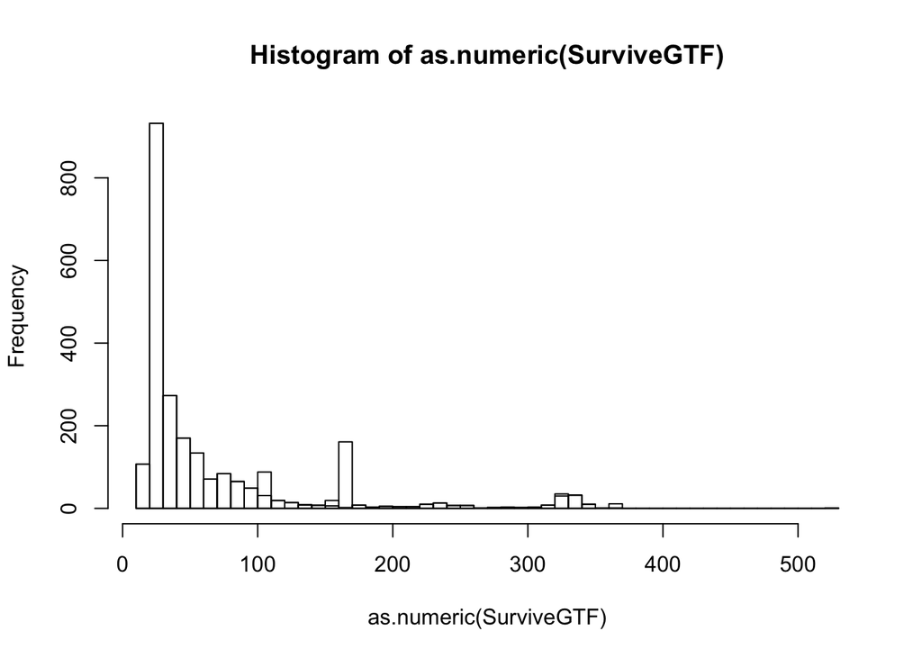

```r
par(mfrow=c(1,1))
SGTF <- hist(as.numeric(SurviveGTF), breaks=50, plot = F)

hist(as.numeric(SurviveGTF), breaks=SGTF$breaks)
hist(as.numeric(GTF), breaks=SGTF$breaks, add=T)
```

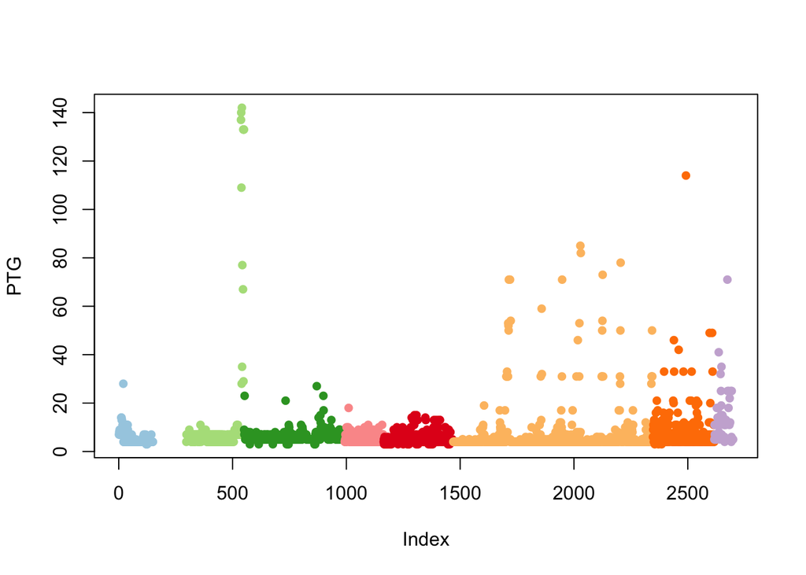

```r
#germination latency
plot(PTG, pch=16, col=col_pal3[Experiment])
```

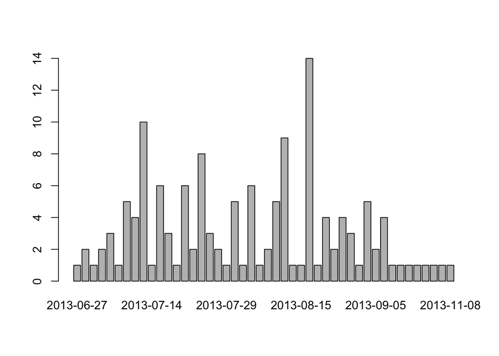

```r
plot(as.factor(FlowDate[Experiment == "field2013"]))
```

```r
table(Pop)
```

```
## Pop
## ADOL AROL CBBG COOL DAJO ESNK MABG MYJO NELO OIBG RABG RACA SPEU TOBG WMBG
##   10   10   20   10   30   53   20   20   30   10   20   20   10   30   30
## AFFR BBCA BINY GSCA MAES PBFR SAES DEES GHIL HCES HMES HZIL IMES ZYIL AUFI
##   70   19  180   31  244   85  174   30   30   30   30   30   30   30  268
## COAU KAMI   AL CBES GMIL M3AU   N3 NZIL  PG6 REIL MAFI NAAU WEAU CGBC FGBC
##  275  185   12   31   31   20    2   38   10   32  128  114  109   10   10
## FRSI LBBC MBBC NTJO PABS RABS RBBC SPNK TYIL
##   10   10   10   10   10   10   10   10    8
```

```r
table(SubSpecies)
```

```
## SubSpecies
##     CAHybrid     confusus       landra    maritimus raphanistrum
##           50           38           85          205         1867
##    rostratus      sativus
##           31          423
```

```r
table(Experiment)
```

```
## Experiment
##  Cult2013    gh2006    IS2013    Lale05 field2012   qst2003   qst2004
##       150       146       254       442       171       306       877
## field2013   sum2010
##       270        83
```

Boxplot of days from planting to flowering of each population

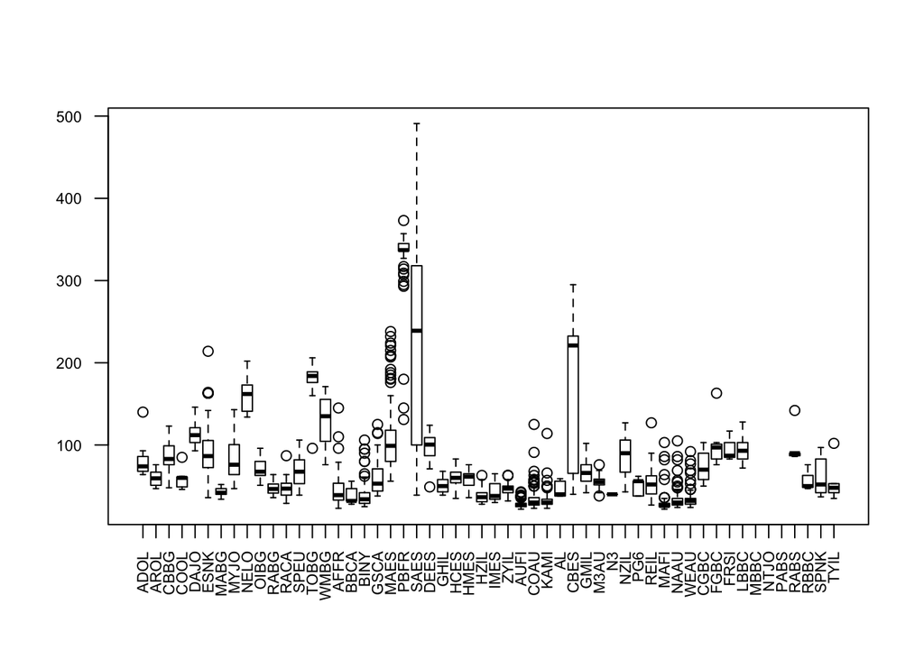

Barplot showing number of individuals per population

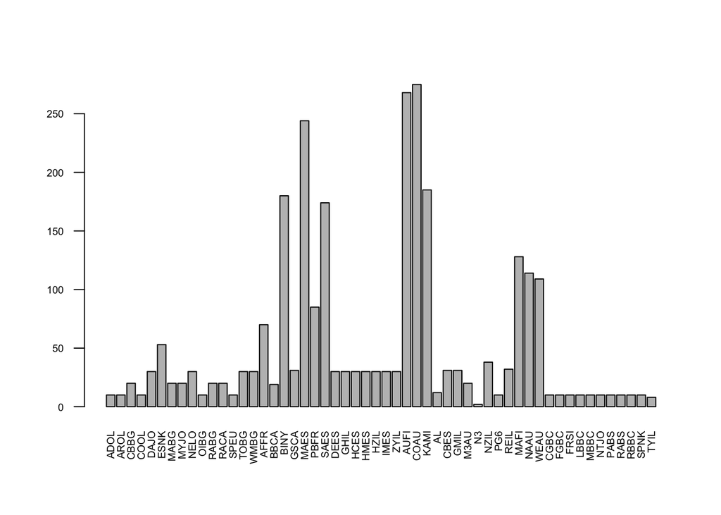